# Generalized Linear Models

STA 631 – Statistical Modeling I

Author

Andrew DiLernia

## Learning Objectives

- Identify the three components of a Generalized Linear Model (GLM): the random component, systematic component, and link function
- Select an appropriate model for different scenarios within the GLM framework
- State the Poisson loglinear regression model for counts and rates
- Assess the assumptions of the Poisson regression model
- Fit and interpret the results of a Poisson regression model
- Obtain and interpret predicted counts and rates
- Assess the fit of a Poisson regression model using appropriate metrics
- Understand off-sets for count models

```r
# Load necessary packages
library(tidyverse)
library(ggthemes)
library(gt)
library(gtExtras)
library(corrr)
library(ggfortify)
library(broom)
library(scales)
library(car)
library(GGally)
library(gtsummary)
library(plotly)
```

```r
# Set ggplot theme for visualizations
theme_set(ggthemes::theme_few())

# Load function for visualizing regression concepts
source("https://raw.githubusercontent.com/dilernia/STA631/main/scripts/regression_functions.R")
```

## Generalized Linear Models (GLMs)

Ordinary multiple linear regression models the relationship between a quantitative response variable $Y$ and explanatory or predictor variables $x_1, x_2, \dots, x_k$ under the assumption that $Y$ is normally distributed with constant variance. Response variables can also be binary outcomes (yes/no), non-negative counts ($0, 1, 2, \dots$), or have skewed distributions where the variance can depend on the mean. In these settings, assuming a normal distribution for $Y$ is inappropriate, so a more general modeling framework is needed.

**Generalized linear models (GLMs)** extend ordinary linear regression to encompass a wider class of distributions, those from the exponential family, for modeling functions of the mean response.

Table 1: Common distributions for modeling continuous and discrete response variables.

| Distribution | Type | Support | Key Features | Example Applications |
| --- | --- | --- | --- | --- |
| Normal (Gaussian) | Continuous | (-∞, ∞) *(All real numbers)* | Symmetric, bell-shaped curve centered at the mean for unbounded negative or positive values. | Human height and adult blood pressure, standardized test scores (e.g., IQ, SAT), daily temperature fluctuations |
| Gamma | Continuous | (0, ∞) *(Strictly positive real numbers)* | Right-skewed distribution for positive continuous values. Variance increases as the mean grows. | Total insurance claim payout amounts, duration of hospital stays, daily or monthly rainfall totals |
| Beta | Continuous | (0, 1) *(Bounded & continuous)* | Distribution for values constrained between 0 and 1 (or 0% to 100%). Useful for modeling unknown probabilities, rates, or proportions. | Website click-through rates (CTR), proportion of a city’s population infected, customer conversion rates |
| Binomial | Discrete | {0, 1, 2, …, *n*} *(Integers from 0 up to n)* | Counts the total number of “successes” across a fixed number (*n*) of independent trials, each with the same probability (*p*) of success. Useful for modeling a binary outcome. | Number of defective parts in a batch of 100, survey respondents out of 500 supporting a policy, patients cured out of 30 in a clinical trial |
| Negative binomial | Discrete | {0, 1, 2, 3, …} *(Non-negative integers)* | Counts the number of failures occurring before reaching a target number of successes. Also used for count data where variance is larger than the mean (overdispersion). | Number of cold sales calls needed to get 5 buyers, RNA sequencing read counts per gene, minor car accidents a driver accumulates |
| Poisson | Discrete | {0, 1, 2, 3, …} *(Non-negative integers)* | Counts how many times an independent event occurs within a fixed window of time or space. Assumes the variance equals the mean (Var = μ). | Website visits per minute, 911 emergency calls per hour, potholes per mile of highway |

Some examples where generalized linear models are useful include:

1. Modeling the number of emergency room visits a patient makes in a year using their age, insurance status, and number of chronic conditions. ⚕️🏥
2. Estimating the probability that a borrower defaults on a loan using their credit score, debt-to-income ratio, and employment status. 💼 💸
3. Analyzing the number of male “satellite” horseshoe crabs clustering around a nesting female crab based on her carapace width, weight, color, and spine condition. 🦀 🌊
4. Modeling the number of bike rentals in a city during a given time period using the outdoor temperature, wind speed, season, and time of day. 🚲 🌤️

**Tip**

For examples a. through d. above, identify the response variable $Y$, whether it is a binary outcome or a count outcome, and a reasonable distribution (e.g., Binomial or Poisson) to assume for $Y$.

### Three Components of a GLM

Every generalized linear model consists of three fundamental components:

1. **Random Component**: Specifies an assumption of $n$ independent observations $(y_1, y_2, \dots, y_n)$ from a distribution in the exponential family. Examples include the normal distribution for continuous responses or the binomial distribution for binary responses.
2. **Systematic Component**: Specifies how the $k$ explanatory or predictor variables $x_1, x_2, \dots, x_k$ combine linearly to form the linear predictor, $\eta = \beta_0 + \beta_1 x_{1} + \beta_2 x_{2} + \dots + \beta_k x_{k}$.
3. **Link Function**: Specifies a monotonic, differentiable function $g(\cdot)$ that connects the expected value (mean) of the response variable, denoted $\mathbb{E}[Y]$, to the linear predictor, $\eta$.

Table 2: Common Generalized Linear Models by Random Component and Link Function.

| Random Component | Link Function g(⋅) | Response Type | Model Name |
| --- | --- | --- | --- |
| Normal | μ | Continuous | Multiple linear Regression |
| Binomial | π | Binary (0 or 1) | Linear probability model |
| Binomial | log[π / (1 − π)] | Binary (0 or 1) | Logistic regression |
| Binomial | Φ⁻¹(π) | Binary (0 or 1) | Probit regression |
| Poisson | log(μ) | Count (0, 1, 2, ...) | Poisson regression |
| Negative binomial | log(μ) | Overdispersed count | Negative binomial regression |
| Gamma | 1 / μ | Continuous positive (0, ∞) | Gamma regression |
| Beta | log[μ / (1 − μ)] | Continuous proportion (0, 1) | Beta regression |

**Tip**

Which random component and link function would be most appropriate for each scenario below?

1. Suppose we are modeling the daily number of pets adopted from a local animal shelter based on the day of the week and the amount spent on social media advertising. Prior knowledge indicates that the variance of the daily adoption counts is much larger than the average. 🐕 🐈
2. Our analytics team is analyzing how smartphone batteries deplete over the course of a day. We want to model the remaining battery percentage based on the hours since the phone was last fully charged, the age of the phone, and the phone model (iPhone, Google Pixel, or Samsung Galaxy). 📱🔋
3. Suppose we want to model the daily number of unique visitors to a news website. It is important to understand how visitor counts change based on the day of the week and the number of articles on the site. It is known that the daily visits occur at a constant average rate where the variance roughly equals the mean. 📰 🌐
4. An epidemiologist is modeling the daily number of new incident cases in different regions during a pandemic based on region populations, regional population density, and a mobility index. Viral disease incidence counts often exhibit overdispersion. 🦠 😷
5. Suppose we want to build a predictive model for the Detroit Lions football team’s upcoming season to forecast whether they will win or lose each game. Our model will include both teams’ win percentage from the previous year, and whether the game is played at home or away. 🦁 🏈

#### Advantages of GLMs vs. Transforming the Data

One approach for analyzing non-normal or heteroskedastic data with ordinary linear regression is to transform the response variable $Y$, e.g., $\log(Y)$, and then to assume that the transformed response is approximately normal with constant variance. The GLM framework provides several advantages over such an approach:

- **Separate specification of linearity and variance**: In a GLM, the choice of the link function $g(\cdot)$ is separate from the assumed distribution of $Y$. If a link function makes the relationship with the predictors linear, it does not also have to stabilize the variance or imply normality.
- **Natural handling of boundary values**: For count data, $y = 0$ is a common and valid outcome. A log-transformation of $Y$ fails when $y = 0$ since $\log(0)$ is undefined, whereas a Poisson GLM models $\log(\mathbb{E}[Y])$, which is well-defined whenever the expected count $\mu > 0$.
- **Preservation of distribution support and boundaries**: Choice of a proper link function with GLMs ensures that predicted values $\hat{\mu}$ adhere to the support or boundaries of the assumed distribution (e.g., keeping predicted probabilities strictly within $(0, 1)$ using a logit link, or expected counts strictly positive within $(0, \infty)$ using a log link).

## Poisson Regression for Counts and Rates

We have seen how we can use multiple linear regression when the response variable $Y$ is quantitative, continuous, and unbounded. We have also seen how we can use logistic regression to model a binary response variable. When the response variable $Y$ is a count ($0, 1, 2, \dots$), a common approach is to assume a Poisson distribution for $Y$. A random variable $Y$ following a Poisson distribution with mean parameter $\mu > 0$, denoted $Y \sim \text{Poisson}(\mu)$, has probability mass function (PMF):

$$f(y; \mu) = \Pr(Y = y) = \frac{e^{-\mu} \mu^y}{y!}, \qquad y = 0, 1, 2, \dots$$

A PMF gives the exact probability that a discrete random variable will equal a specific value. For example, suppose a rideshare platform like Lyft receives an average of $\mu = 4$ pickup requests per 1-hour interval in a downtown zone. If the number of requests per hour follows a Poisson distribution, then the probability of observing exactly $y = 6$ requests during a specific 1-hour window can be calculated as:

$$\Pr(Y = 6) = \frac{e^{-4} \cdot 4^6}{6!} = \frac{0.018316 \cdot 4096}{720} \approx 0.1042 \quad (10.42\%)$$

This means there is roughly a $10.42\%$ chance of receiving 6 requests in any given 1-hour interval.

**Tip**

1. For the rideshare scenario, calculate the probability of observing 1 request in an hour.
2. For the rideshare scenario, calculate the probability of observing 0 requests in an hour.
3. What is the probability of observing 1 or fewer requests in an hour?

A key property of the Poisson distribution is that its **mean and variance are equal**:

$$\mathbb{E}[Y] = \text{Var}(Y) = \mu$$

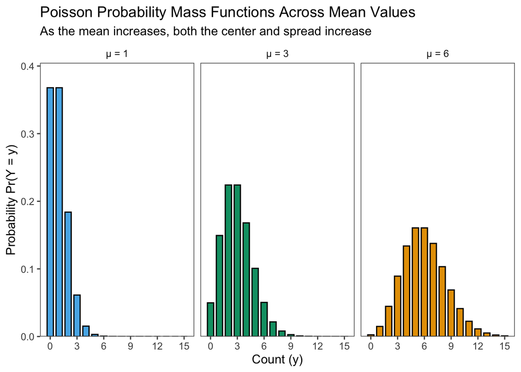

### Poisson Regression

Since an average count $\mu$ must be positive ($\mu > 0$), modeling $\mu$ with the identity link $g(\mu) = \mu$ can lead to negative predicted counts. Instead, we model the natural log of the mean, which can take any real value in $(-\infty, \infty)$. A Poisson GLM with a log link is called a Poisson loglinear model or more commonly a Poisson regression model.

A general statement of the assumed theoretical Poisson regression model with $k$ predictors is:

$$\log(\mu) = \beta_0 + x_1\beta_1 + x_2\beta_2 + \dots + x_k\beta_k,$$

where:

- $Y \sim \text{Poisson}(\mu)$ is our count response variable with expected value (mean) $\mu = \mathbb{E}[Y]$
- $\log(\cdot)$ is the natural log function
- $x_j$ is the $j^{th}$ predictor for $j = 1, 2, \dots, k$

An equivalent formulation of the Poisson regression model is:

$$\mu = \exp(\beta_0 + x_1\beta_1 + x_2\beta_2 + \dots + x_k\beta_k) = e^{\beta_0} e^{x_1\beta_1} e^{x_2\beta_2} \cdots e^{x_k\beta_k}.$$

When providing a statement of the theoretical or assumed Poisson regression model, the terms of the model are expressed using general notation, but the response variable and the predictor variables should be specified for the given context. Also observe that, like logistic regression, the statement of the GLM for the mean $\mu$ does not include an additive normal error term $\varepsilon$.

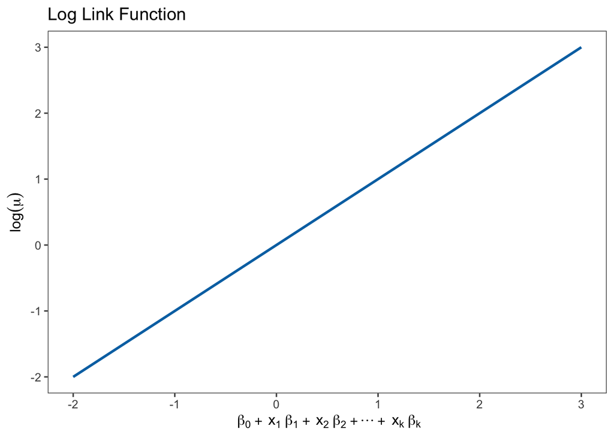

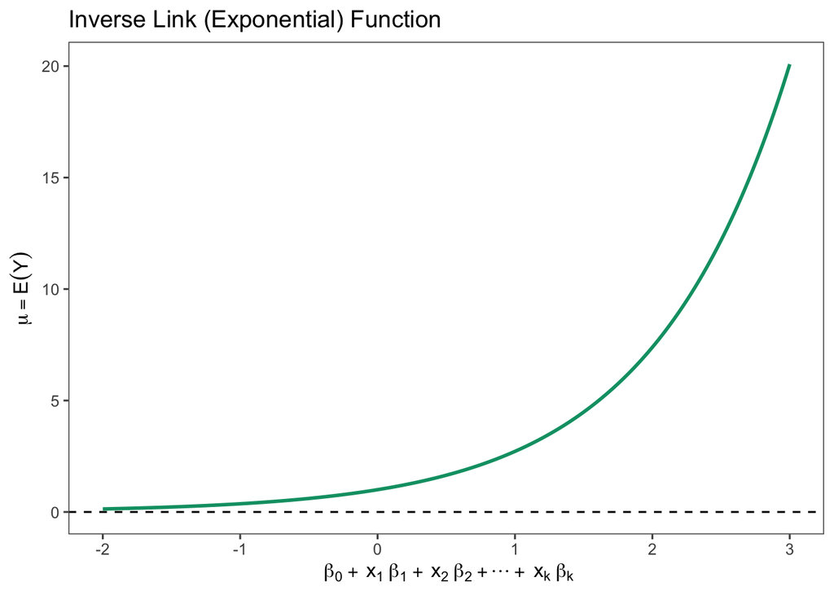

A statement of the estimated Poisson regression equation is:

$$\log(\hat{\mu}) = \hat{\beta}_0 + x_1\hat{\beta}_1 + x_2\hat{\beta}_2 + \dots + x_k\hat{\beta}_k,$$

or equivalently:

$$\hat{\mu} = \exp(\hat{\beta}_0 + x_1\hat{\beta}_1 + x_2\hat{\beta}_2 + \dots + x_k\hat{\beta}_k),$$

where $\hat{\mu}$ is the estimated or predicted mean count of the response variable $Y$ and $x_j$ is the $j^{th}$ predictor for $j = 1, 2, \dots, k$. When providing a statement of the estimated Poisson regression model, the $\hat{\beta}$ terms should be replaced with corresponding numerical estimates from the model output, and the estimated response and predictor variables should be specified for the given context.

### Maximum Likelihood Estimation

Assuming we have $n$ independent observations $y_1, y_2, \dots, y_n$ with $Y_i \sim \text{Poisson}(\mu_i)$, the **likelihood function** is the product of the individual Poisson probability mass functions:

$$L(\beta_0, \beta_1, \dots, \beta_k \mid \mathbf{y}) = \prod_{i=1}^{n} \frac{e^{-\mu_i} \mu_i^{y_i}}{y_i!},$$

where $\mu_i = \exp(\beta_0 + \beta_1 x_{i1} + \beta_2 x_{i2} + \dots + \beta_k x_{ik})$. Taking the natural logarithm yields the **log-likelihood function**:

$$\ell(\boldsymbol{\beta} \mid \mathbf{y}) = \sum_{i=1}^{n} \big(y_i \log(\mu_i) - \mu_i - \log(y_i!)\big).$$

As with logistic regression, since there is no closed-form solution for the parameter values $\hat{\beta}_0, \hat{\beta}_1, \dots, \hat{\beta}_k$ that maximize this log-likelihood, statistical software computes the maximum likelihood estimates (MLEs) numerically using an iterative algorithm such as iteratively reweighted least squares or Fisher scoring.

### Poisson Regression Assumptions

To obtain reliable coefficient estimates and valid statistical inference (standard errors, confidence intervals, and p-values), Poisson regression relies on the following assumptions:

1. **Count response**: The response variable $Y$ is a count (e.g., $0, 1, 2, \dots$).
2. **Independent observations**: Observations are independent of one another and randomly sampled from the population of interest.
3. **Linearity**: The natural log of the mean response, $\log(\mu)$, is a linear function of the predictors.
4. **Mean equals variance (Equidispersion)**: At each setting of the predictors, the conditional variance of the response equals its conditional mean, $\text{Var}(Y_i) = \mu_i$.
5. **No multicollinearity**: Predictor variables should not be highly correlated with one another. As in logistic regression, we check this using the adjusted generalized variance inflation factor, $\text{GVIF}_j^{\frac{1}{2\text{df}}}$, where values exceeding $\sqrt{5} \approx 2.24$ indicate potential multicollinearity issues.

### Interpreting Estimated Poisson Coefficients

Since the Poisson regression model uses a log link, the effects of predictors on the expected count $\mu$ are **multiplicative** rather than additive. Specifically, increasing $x_j$ by 1 unit while holding all other predictors constant changes $\log(\mu)$ by $\beta_j$, which multiplies $\mu$ by $e^{\beta_j}$:

$$\mu(x_j + 1) = \exp\big(\beta_0 + \dots + \beta_j(x_j + 1) + \dots\big) = \mu(x_j) \cdot e^{\beta_j}.$$

The quantity $e^{\hat{\beta}_j}$ is often called the **rate ratio** (or *incidence rate ratio*, IRR).

**General interpretation for $\hat{\beta}_j$ (quantitative predictor)**: *For every 1 unit increase in $x_j$, we expect the mean count of $Y$ to multiply by $e^{\hat{\beta}_j}$ (equivalently, to change by $(e^{\hat{\beta}_j} - 1) \times 100\%$), holding all other predictors constant.*

**General interpretation for $\hat{\beta}_j$ (categorical dummy predictor)**: *For observations in category $j$ compared to the baseline / reference category, we expect the mean count of $Y$ to multiply by $e^{\hat{\beta}_j}$, holding all other predictors constant.*

**General interpretation for $\hat{\beta}_0$**: *The expected count of $Y$ given that $x_1$ through $x_k$ are all 0 is $e^{\hat{\beta}_0}$.*

As in linear and logistic regression, interpreting the intercept $\hat{\beta}_0$ is only sensible when all quantitative predictors being 0 is within the range of the observed data; otherwise, it is considered **extrapolation**.

### Poisson Regression for Rates Using Offsets

Often, a response count $Y_i$ is observed over a varying amount of exposure $t_i$, such as an amount of time (e.g., the number of hours in a time period or patient follow-up months) or spatial area. When $t_i$ varies across observations, it is often natural to model the **expected rate** of occurrence per unit of exposure, $\mu_i / t_i$, rather than the raw count:

$$\log\left(\frac{\mu_i}{t_i}\right) = \beta_0 + \beta_1 x_{i1} + \beta_2 x_{i2} + \dots + \beta_k x_{ik}.$$

Using properties of logarithms, $\log(\mu_i / t_i) = \log(\mu_i) - \log(t_i)$, we can rewrite this model as:

$$\log(\mu_i) = \log(t_i) + \beta_0 + \beta_1 x_{i1} + \beta_2 x_{i2} + \dots + \beta_k x_{ik},$$

or equivalently on the expected count scale:

$$\mu_i = t_i \exp(\beta_0 + \beta_1 x_{i1} + \beta_2 x_{i2} + \dots + \beta_k x_{ik}).$$

The adjustment term $\log(t_i)$ is called an **offset**: it acts like a predictor variable in the linear predictor whose regression coefficient is fixed at exactly $1.0$.

**Tip**

1. What would the offset be for the pandemic example provided earlier?
2. Would any of the other provided scenarios as given have an offset?

## Example: Washington, D.C. Bike Rentals 🚲 🌤️

To illustrate generalized linear models for count data, we will analyze data on $2{,}193$ time periods across $731$ calendar days (2011 to 2012) from the Capital Bikeshare system in Washington, D.C. The data were sourced from the UCI Machine Learning Repository Bike Sharing Dataset and aggregated to three periods per day: `Morning` (4:00 am to 11:59 am), `Afternoon` (12:00 pm to 5:59 pm), and `Evening` (6:00 pm to 3:59 am).

Specifically, we will use Poisson regression to model the total number of bike rentals during each period (`total_rentals`) as our response variable using the average outdoor temperature in degrees Fahrenheit (`temperature_f`) and the period of the day (`time_of_day`) as predictors.

Let’s import the data from GitHub using the code below.

```r
# Importing DC bike rentals data from GitHub
dc_bike_rentals <- read_csv("https://raw.githubusercontent.com/dilernia/STA631/refs/heads/main/data/dc_bike_rentals.csv")
```

### Exploratory Data Analysis

Below is a data dictionary for the DC bike rentals data set, followed by a preview of the first five rows.

Table 3: Data dictionary for the DC bike rentals data set.

Data Dictionary: DC Bike Rentals

Capital Bikeshare rentals in Washington, D.C., by date and time of day, 2011 to 2012

| Variable | Description |
| --- | --- |
| date | Calendar date of the rentals |
| day_of_week | Day of the week for the date |
| time_of_day | Period of the day: morning (4:00 am to 11:59 am), afternoon (12:00 pm to 5:59 pm), or evening (6:00 pm to 3:59 am) |
| season | Season of the year, as coded in the source data |
| working_day | Whether the day was a working day (neither a weekend nor a holiday) |
| temperature_f | Average temperature during the period, in degrees Fahrenheit |
| wind_speed_mph | Average wind speed during the period, in miles per hour |
| total_rentals | Total bike rentals (casual plus registered) during the period; response variable |

Source: UCI Machine Learning Repository, Bike Sharing Dataset (hourly data), aggregated to date by time of day.

Table 4: First five rows of the DC bike rentals data set.

| date | day_of_week | time_of_day | season | working_day | temperature_f | wind_speed_mph | total_rentals |
| --- | --- | --- | --- | --- | --- | --- | --- |
| 2011-01-01 | Saturday | Morning | Winter | Non-working day | 40.9 | 3.3 | 121 |
| 2011-01-01 | Saturday | Afternoon | Winter | Non-working day | 54.8 | 12.1 | 554 |
| 2011-01-01 | Saturday | Evening | Winter | Non-working day | 46.5 | 6.2 | 310 |
| 2011-01-02 | Sunday | Morning | Winter | Non-working day | 51.2 | 9.6 | 157 |
| 2011-01-02 | Sunday | Afternoon | Winter | Non-working day | 47.2 | 8.0 | 442 |

Let’s first examine the distribution of our count response variable, `total_rentals`, across all $2{,}193$ date and time-of-day periods.

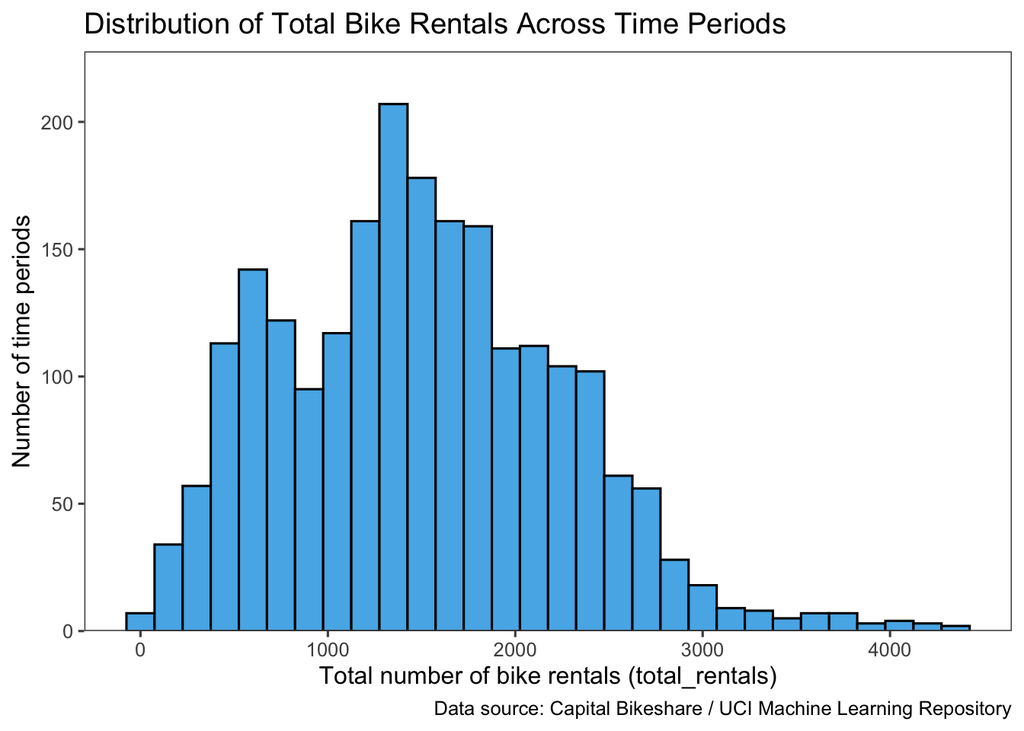

```r
# Creating histogram of total_rentals
dc_bike_rentals |>
  ggplot(aes(x = total_rentals)) +
  geom_histogram(binwidth = 150, fill = "#56B4E9", color = "black") +
  scale_y_continuous(expand = expansion(mult = c(0, 0.1))) +
  labs(
    title = "Distribution of Total Bike Rentals Across Time Periods",
    x = "Total number of bike rentals (total_rentals)",
    y = "Number of time periods",
    caption = "Data source: Capital Bikeshare / UCI Machine Learning Repository"
  )
```

Next, let’s visualize the relationship between `temperature_f` and `total_rentals` with a Poisson regression curve (log link).

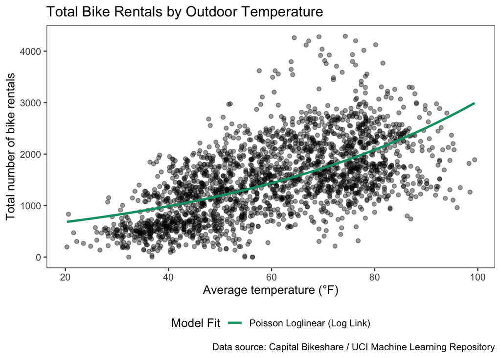

```r
# Creating scatter plot of total_rentals by temperature_f with fitted curve
dc_bike_rentals |>
  ggplot(aes(x = temperature_f, y = total_rentals)) +
  geom_point(alpha = 0.4) +
  geom_smooth(
    aes(color = "Poisson Loglinear (Log Link)"),
    method = "glm",
    method.args = list(family = "poisson"),
    se = FALSE
  ) +
  scale_color_manual(
    name = "Model Fit",
    values = c("Poisson Loglinear (Log Link)" = "#009E73")
  ) +
  labs(
    title = "Total Bike Rentals by Outdoor Temperature",
    x = "Average temperature (°F)",
    y = "Total number of bike rentals",
    caption = "Data source: Capital Bikeshare / UCI Machine Learning Repository"
  ) +
  theme(legend.position = "bottom")
```

Let’s also examine how `total_rentals` varies across the three periods of the day (`time_of_day`), both visually and using descriptive statistics.

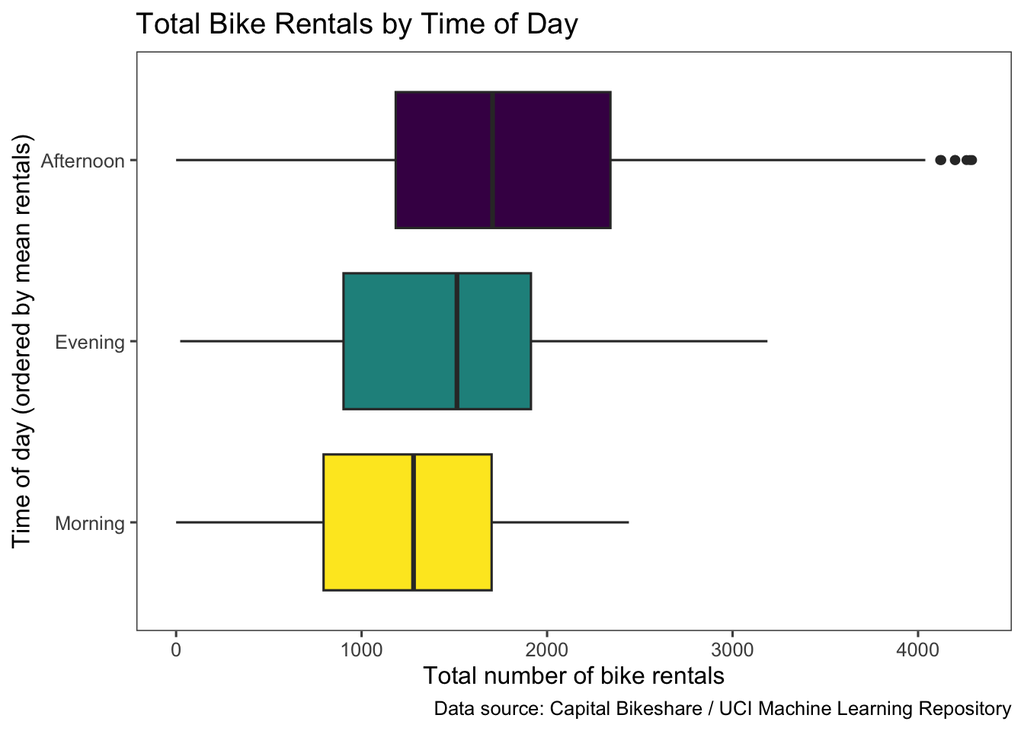

```r
# Creating side-by-side box plots of total_rentals by time_of_day
dc_bike_rentals |>
  ggplot(aes(x = fct_reorder(time_of_day, total_rentals, .fun = mean), y = total_rentals, fill = time_of_day)) +
  geom_boxplot(show.legend = FALSE) +
  coord_flip() +
  scale_fill_viridis_d() +
  labs(
    title = "Total Bike Rentals by Time of Day",
    x = "Time of day (ordered by mean rentals)",
    y = "Total number of bike rentals",
    caption = "Data source: Capital Bikeshare / UCI Machine Learning Repository"
  )
```

```r
# Calculating descriptive statistics stratified by time_of_day
bike_time_statistics <- dc_bike_rentals |>
  group_by(time_of_day) |>
  summarize(
    N = n(),
    Minimum = min(total_rentals, na.rm = TRUE),
    Q1 = quantile(total_rentals, na.rm = TRUE, probs = 0.25),
    Median = median(total_rentals, na.rm = TRUE),
    Q3 = quantile(total_rentals, na.rm = TRUE, probs = 0.75),
    Maximum = max(total_rentals, na.rm = TRUE),
    Mean = mean(total_rentals, na.rm = TRUE),
    Variance = var(total_rentals, na.rm = TRUE),
    SD = sd(total_rentals, na.rm = TRUE)
  )

# Printing table of statistics stratified by time_of_day
bike_time_statistics |>
  gt() |>
  fmt_number(
    columns = c(Q1, Median, Q3, Mean, Variance, SD),
    decimals = 2,
    drop_trailing_zeros = TRUE
  )
```

Table 5: Summary statistics for total bike rentals stratified by time of day.

| time_of_day | N | Minimum | Q1 | Median | Q3 | Maximum | Mean | Variance | SD |
| --- | --- | --- | --- | --- | --- | --- | --- | --- | --- |
| Afternoon | 731 | 0 | 1,184 | 1,706 | 2,341.5 | 4291 | 1,768.46 | 707,965.66 | 841.41 |
| Evening | 731 | 22 | 902.5 | 1,514 | 1,913 | 3188 | 1,469.12 | 490,335.3 | 700.24 |
| Morning | 731 | 0 | 795 | 1,280 | 1,701 | 2441 | 1,266.77 | 340,118.08 | 583.2 |

We can also examine the pairwise correlations and scatter plot matrix for the quantitative variables in the data set.

```r
# Calculating correlations
correlations_table <- dc_bike_rentals |>
  dplyr::select(where(is.numeric)) |>
  corrr::correlate(diagonal = 1)

# Printing table of correlations
correlations_table |>
  gt() |>
  fmt_number(
    columns = everything(),
    decimals = 2,
    drop_trailing_zeros = FALSE
  )
```

Table 6: Table of pairwise correlations among quantitative variables.

| term | temperature_f | wind_speed_mph | total_rentals |
| --- | --- | --- | --- |
| temperature_f | 1.00 | −0.06 | 0.60 |
| wind_speed_mph | −0.06 | 1.00 | −0.09 |
| total_rentals | 0.60 | −0.09 | 1.00 |

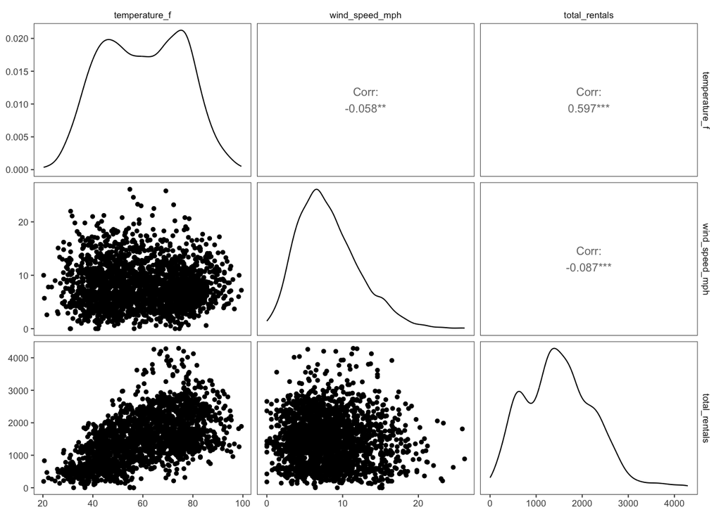

```r
# Create scatter plot matrix
dc_bike_rentals |>
  dplyr::select(where(is.numeric)) |>
  ggpairs() +
  theme_few(base_size = 8)
```

**Tip**

1. Based on the histogram and scatter plot of `total_rentals`, why might an ordinary multiple linear regression model assuming normally distributed errors with constant variance be inappropriate for this response variable?
2. Based on the scatter plot and Table 5, what can we say about the relationship between `temperature_f`, `time_of_day`, and `total_rentals`? Notice that the spread (variability) of `total_rentals` increases at warmer temperatures where the mean rental count is higher.
3. Compare the sample `Mean` and sample `Variance` columns across the periods of the day in Table 5. Does the Poisson equidispersion assumption ($\text{Var}(Y) = \mu$) appear to hold?
4. Provide a statement of our assumed / theoretical Poisson loglinear regression model using the total number of bike rentals (`total_rentals`) as our response variable and `temperature_f` and `time_of_day` as our predictors. How many dummy variables are needed to represent `time_of_day`?

### Fitting a Model

Let’s fit the Poisson loglinear regression model using `total_rentals` as the response and `temperature_f` and `time_of_day` as predictors with the `glm()` function and `family = "poisson"`.

```r
# Fitting Poisson loglinear regression model
poisson_model <- glm(total_rentals ~ temperature_f + time_of_day,
                     family = "poisson",
                     data = dc_bike_rentals)
```

We can visualize the fitted Poisson regression curves showing the predicted mean count $\hat{\mu}$ across `temperature_f` for each period of the day.

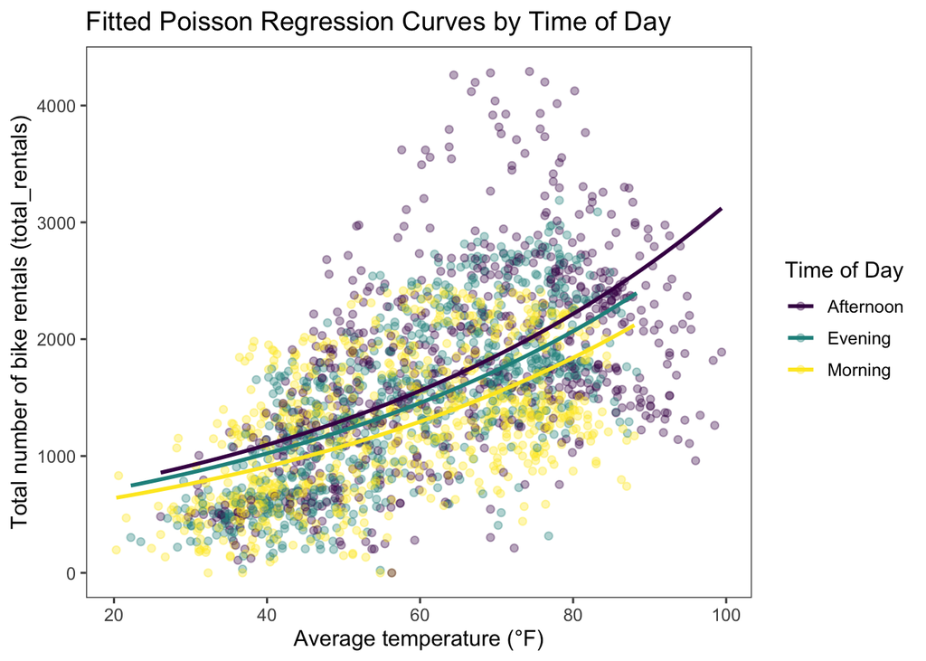

```r
# Creating grid of values for plotting fitted curves across time_of_day
prediction_grid <- dc_bike_rentals |>
  group_by(time_of_day) |>
  reframe(temperature_f = seq(min(temperature_f), max(temperature_f), length.out = 50))

prediction_grid <- prediction_grid |>
  mutate(predicted_rentals = predict(poisson_model, newdata = prediction_grid, type = "response"))

# Plotting fitted Poisson regression curves by time_of_day
dc_bike_rentals |>
  ggplot(aes(x = temperature_f, y = total_rentals, color = time_of_day)) +
  geom_point(alpha = 0.35) +
  geom_line(data = prediction_grid, aes(y = predicted_rentals), linewidth = 1) +
  scale_color_viridis_d(name = "Time of Day") +
  labs(
    title = "Fitted Poisson Regression Curves by Time of Day",
    x = "Average temperature (°F)",
    y = "Total number of bike rentals (total_rentals)"
  )
```

Next, let’s examine diagnostic plots and multicollinearity metrics to evaluate how well the model assumptions are satisfied.

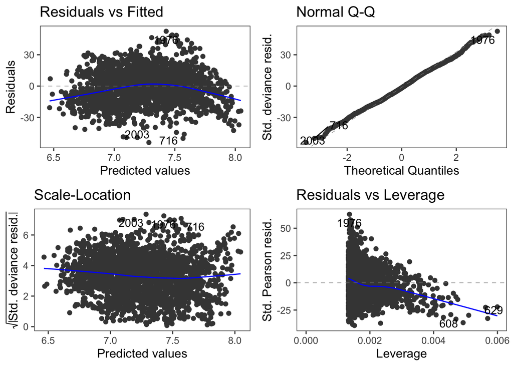

```r
# Diagnostic plots for the Poisson GLM
autoplot(poisson_model, label.repel = TRUE)
```

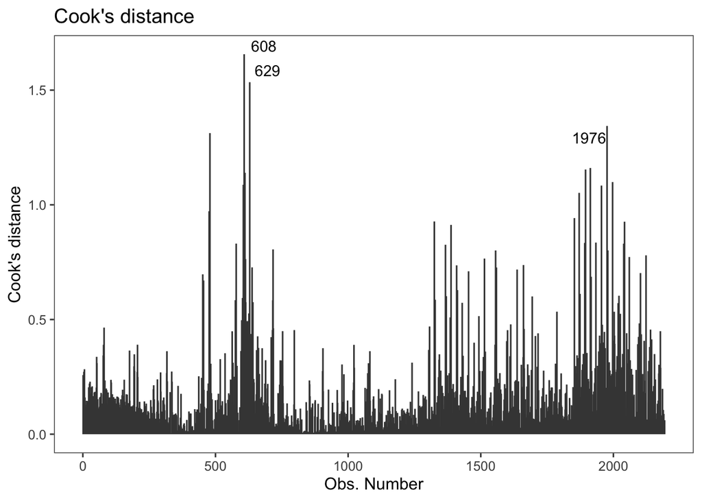

```r
# Cook's Distance plot
autoplot(poisson_model, which = 4, label.repel = TRUE)@plots[[1]]
```

```r
# Checking generalized variance inflation factor (GVIF) values
car::vif(poisson_model) |>
  as_tibble(rownames = "Predictor") |>
  gt() |>
  fmt_number(columns = where(is.numeric), decimals = 3)
```

| Predictor | GVIF | Df | GVIF^(1/(2*Df)) |
| --- | --- | --- | --- |
| temperature_f | 1.063 | 1.000 | 1.031 |
| time_of_day | 1.063 | 2.000 | 1.015 |

**Tip**

Indicate whether each assumption for fitting the Poisson regression model is met, providing specific evidence from the exploratory tables, diagnostic plots, and GVIF values.

### Interpreting Model Estimates

Below is the output for our Poisson regression model using `total_rentals` as the response variable and `temperature_f` and `time_of_day` as predictors. First, Table 7 displays the estimated coefficients ($\hat{\beta}_j$) on the log-count scale; second, Table 8 displays the exponentiated coefficients ($e^{\hat{\beta}_j}$, the rate ratios) for direct multiplicative interpretation.

```r
# Printing model output on the log scale
poisson_model |>
  tbl_regression(intercept = TRUE, estimate_fun = label_style_number(digits = 3)) |>
  add_vif() |>
  add_glance_source_note()
```

Table 7: Poisson regression model estimates.

| **Characteristic** | **log(IRR)** | **95% CI** | **p-value** | **GVIF** | **Adjusted GVIF**<sup>1</sup> |
| --- | --- | --- | --- | --- | --- |
| (Intercept) | 6.294 | 6.289, 6.299 | <0.001 |  |  |
| temperature_f | 0.018 | 0.018, 0.018 | <0.001 | 1.1 | 1.0 |
| time_of_day |  |  |  | 1.1 | 1.0 |
| Afternoon | — | — |  |  |  |
| Evening | -0.069 | -0.072, -0.067 | <0.001 |  |  |
| Morning | -0.186 | -0.189, -0.183 | <0.001 |  |  |

<sup>1</sup> GVIF[^1]  
Abbreviations: CI = Confidence Interval, GVIF = Generalized Variance Inflation Factor, IRR = Incidence Rate Ratio  
Null deviance = 851,899; Null df = 2,192; Log-likelihood = -281,001; AIC = 562,010; BIC = 562,033; Deviance = 542,313; Residual df = 2,189; No. Obs. = 2,193

```r
# Printing exponentiated model output (rate ratios)
poisson_model |>
  tbl_regression(intercept = TRUE, exponentiate = TRUE, estimate_fun = label_style_number(digits = 3)) |>
  add_vif() |>
  add_glance_source_note()
```

Table 8: Exponentiated Poisson regression model estimates (rate ratios).

| **Characteristic** | **IRR** | **95% CI** | **p-value** | **GVIF** | **Adjusted GVIF**<sup>1</sup> |
| --- | --- | --- | --- | --- | --- |
| (Intercept) | 541.440 | 538.640, 544.253 | <0.001 |  |  |
| temperature_f | 1.018 | 1.018, 1.018 | <0.001 | 1.1 | 1.0 |
| time_of_day |  |  |  | 1.1 | 1.0 |
| Afternoon | — | — |  |  |  |
| Evening | 0.933 | 0.930, 0.935 | <0.001 |  |  |
| Morning | 0.830 | 0.828, 0.833 | <0.001 |  |  |

<sup>1</sup> GVIF[^2]  
Abbreviations: CI = Confidence Interval, GVIF = Generalized Variance Inflation Factor, IRR = Incidence Rate Ratio  
Null deviance = 851,899; Null df = 2,192; Log-likelihood = -281,001; AIC = 562,010; BIC = 562,033; Deviance = 542,313; Residual df = 2,189; No. Obs. = 2,193

**Tip**

1. Using the output in Table 7, provide a statement of the estimated Poisson regression equation. Which period of the day serves as the baseline / reference category?
2. Interpret the estimated slope for `temperature_f` in context on the multiplicative (rate ratio) scale. How much does the expected number of bike rentals change for a $10^\circ\text{F}$ increase in temperature, holding the time of day constant?
3. Interpret the estimated coefficients for the `Evening` period (`time_of_dayEvening`) and the `Morning` period (`time_of_dayMorning`) in context. Why do both have negative estimated coefficients relative to the baseline `Afternoon` period?
4. Interpret the estimated intercept in context. Is this sensible and appropriate to interpret here?
5. What does the model predict the expected number of bike rentals ($\hat{\mu}$) to be on the morning of January 1, 2011 (`date == "2011-01-01"`, `time_of_day == "Morning"`, with `temperature_f = 40.9`)? Use the output in Table 7 to confirm the value in Table 9 below.
6. What is the corresponding raw residual ($y_i - \hat{\mu}_i$) for the morning of January 1, 2011, and what does it mean in this context?

```r
# Displaying predicted count for the morning of January 1, 2011
dc_bike_rentals |>
  augment(x = poisson_model, type.predict = "response") |>
  dplyr::filter(date == as.Date("2011-01-01"), time_of_day == "Morning") |>
  dplyr::select(date, time_of_day, temperature_f, total_rentals, .fitted) |>
  gt() |>
  fmt_number(columns = .fitted, decimals = 2)
```

Table 9: Observed and predicted bike rentals for the morning of January 1, 2011.

| date | time_of_day | temperature_f | total_rentals | .fitted |
| --- | --- | --- | --- | --- |
| 2011-01-01 | Morning | 40.9 | 121 | 924.34 |

We can also obtain predicted counts for new combinations of `temperature_f` and `time_of_day` using the `predict()` function with `type = "response"`.

```r
# Creating data frame of predictor values for a 70°F day
prediction_data <- tibble(
  temperature_f = 70,
  time_of_day = c("Morning", "Afternoon", "Evening")
)

# Obtaining predicted counts on the link and response scales
prediction_data |>
  mutate(
    predicted_log_count = predict(poisson_model, newdata = prediction_data, type = "link"),
    predicted_count = predict(poisson_model, newdata = prediction_data, type = "response")
  ) |>
  gt() |>
  fmt_number(columns = c(predicted_log_count, predicted_count), decimals = 2)
```

Table 10: Predicted bike rental counts for a 70°F day across time-of-day periods.

| temperature_f | time_of_day | predicted_log_count | predicted_count |
| --- | --- | --- | --- |
| 70 | Morning | 7.34 | 1,543.57 |
| 70 | Afternoon | 7.53 | 1,858.83 |
| 70 | Evening | 7.46 | 1,734.14 |

### Modeling Rates with an Offset

Notice that the three `time_of_day` periods span different numbers of hours: `Morning` (4:00 am to 11:59 am) spans $8$ hours, `Afternoon` (12:00 pm to 5:59 pm) spans $6$ hours, and `Evening` (6:00 pm to 3:59 am) spans $10$ hours. Rather than modeling the total count of rentals across periods of unequal length, suppose we want to model the *hourly* rental rate, the expected number of bike rentals per hour, as a function of `temperature_f` and `time_of_day`.

Let $t_i \in \{6, 8, 10\}$ denote the duration (`hours`) of period $i$. The Poisson loglinear rate model is:

$$\log\left(\frac{\mu_i}{t_i}\right) = \beta_0 + \beta_1 x_{i1} + \beta_2 x_{i2} + \beta_3 x_{i3},$$

or equivalently

$$\log(\mu_i) = \log(t_i) + \beta_0 + \beta_1 x_{i1} + \beta_2 x_{i2} + \beta_3 x_{i3},$$

where $\log(t_i)$ is included as an **offset** term via `offset(log(hours))`.

```r
# Adding number of hours in each time_of_day period
dc_bike_rentals <- dc_bike_rentals |>
  mutate(
    hours = case_when(
      time_of_day == "Morning"   ~ 8,
      time_of_day == "Afternoon" ~ 6,
      time_of_day == "Evening"   ~ 10
    )
  )

# Fitting Poisson regression model for the hourly rental rate using an offset
poisson_rate_model <- glm(total_rentals ~ temperature_f + time_of_day + offset(log(hours)),
                          family = "poisson",
                          data = dc_bike_rentals)

# Printing rate model output
poisson_rate_model |>
  tbl_regression(intercept = TRUE, exponentiate = TRUE, estimate_fun = label_style_number(digits = 3)) |>
  add_glance_source_note()
```

Table 11: Poisson rate regression model output using log(hours) as an offset.

| **Characteristic** | **IRR** | **95% CI** | **p-value** |
| --- | --- | --- | --- |
| (Intercept) | 90.240 | 89.773, 90.709 | <0.001 |
| temperature_f | 1.018 | 1.018, 1.018 | <0.001 |
| time_of_day |  |  |  |
| Afternoon | — | — |  |
| Evening | 0.560 | 0.558, 0.561 | <0.001 |
| Morning | 0.623 | 0.621, 0.625 | <0.001 |

Abbreviations: CI = Confidence Interval, IRR = Incidence Rate Ratio  
Null deviance = 1,116,416; Null df = 2,192; Log-likelihood = -281,001; AIC = 562,010; BIC = 562,033; Deviance = 542,313; Residual df = 2,189; No. Obs. = 2,193

**Tip**

1. Compare the rate ratios for `Evening` ($0.560$) and `Morning` ($0.623$) in Table 11 with those in Table 8 ($0.933$ and $0.830$). Why does `Evening` have a higher total rental count than `Morning`, yet a *lower* hourly rental rate when we account for the duration of each period using `offset(log(hours))`?
2. How does using `offset(log(hours))` differ conceptually from including `log(hours)` as a standard predictor variable with a freely estimated regression coefficient?

### Accounting for Overdispersion: Negative Binomial GLM

In practice, count data can exhibit greater variability than the Poisson distribution allows: the conditional variance is much larger than the conditional mean ($\text{Var}(Y_i) > \mu_i$). This phenomenon is called **overdispersion**.

One cause of overdispersion is **unobserved heterogeneity** among observations. Even when observations share the same measured predictor values, unmeasured factors can cause their true underlying Poisson means to vary, creating a mixture of Poisson distributions whose overall variance exceeds its mean.

- **How to detect overdispersion**: Compare the **sample variance** and **sample mean** of the count response within groups or bins of the predictors. If the sample variance is much larger than the sample mean, overdispersion is present.
- **Consequences and remedies**: When the loglinear model for the mean $\mu$ is correctly specified but the data are overdispersed, the Poisson maximum likelihood estimates $\hat{\beta}_j$ remain consistent in large samples, but **their standard errors are underestimated (too small)**, which makes confidence intervals too narrow and p-values artificially small. A common remedy is to fit a negative binomial GLM, which introduces an extra dispersion parameter $\gamma > 0$ so that the variance can grow quadratically with the mean:
  $$\mathbb{E}[Y] = \mu, \qquad \text{Var}(Y) = \mu + \gamma \mu^2.$$
  As $\gamma$ goes to 0, the negative binomial GLM converges to the Poisson GLM.

Earlier, we saw in Table 5 that the sample variance of `total_rentals` is hundreds of times larger than the sample mean within every time-of-day period, indicating pronounced overdispersion ($\text{Var}(Y_i) > \mu_i$). To account for this extra variability, we can fit a negative binomial GLM with a log link.

```r
# Fitting a negative binomial GLM to account for overdispersion
nb_model <- MASS::glm.nb(total_rentals ~ temperature_f + time_of_day,
                         data = dc_bike_rentals)

# Printing negative binomial model output
nb_model |>
  tbl_regression(intercept = TRUE, estimate_fun = label_style_number(digits = 3)) |>
  add_glance_source_note()
```

Table 12: Negative binomial GLM estimates on the log-count scale.

| **Characteristic** | **log(IRR)** | **95% CI** | **p-value** |
| --- | --- | --- | --- |
| (Intercept) | 6.109 | 6.017, 6.202 | <0.001 |
| temperature_f | 0.021 | 0.019, 0.022 | <0.001 |
| time_of_day |  |  |  |
| Afternoon | — | — |  |
| Evening | -0.085 | -0.134, -0.037 | <0.001 |
| Morning | -0.158 | -0.207, -0.109 | <0.001 |

Abbreviations: CI = Confidence Interval, IRR = Incidence Rate Ratio  
Null deviance = 3,401; Null df = 2,192; Log-likelihood = -17,206; AIC = 34,422; BIC = 34,451; Deviance = 2,314; Residual df = 2,189; No. Obs. = 2,193

**Tip**

1. Compare the estimated coefficients and 95% confidence intervals in the negative binomial model (Table 12) with those from the Poisson model (Table 7). How does accounting for overdispersion affect the width of the confidence intervals for `temperature_f` and `time_of_day`?
2. Why do the standard errors become much larger (and the confidence intervals wider) in the negative binomial model compared to the Poisson model?
3. Provide and interpret the estimated coefficients for the negative binomial model.

### Assessing Model Fit and Model Selection

When building a GLM with several candidate predictors or distributional assumptions, we want a model that effectively explains variation in the response variable without overfitting the data. As with linear and logistic regression, we can use the Bayesian Information Criterion (BIC) to compare candidate models. Models with lower BIC values are preferred.

Let’s compare four candidate models for `total_rentals`:

1. **Model 1 (`poisson_temp`)**: Poisson GLM (log link) with `temperature_f` only
2. **Model 2 (`poisson_time`)**: Poisson GLM (log link) with `time_of_day` only
3. **Model 3 (`poisson_model`)**: Poisson GLM (log link) with `temperature_f` and `time_of_day`
4. **Model 4 (`nb_model`)**: Negative binomial GLM (log link) with `temperature_f` and `time_of_day`

```r
# Fitting single-predictor Poisson model (temperature_f)
poisson_temp <- glm(total_rentals ~ temperature_f,
                    family = "poisson",
                    data = dc_bike_rentals)

poisson_temp |>
  tbl_regression(intercept = TRUE, estimate_fun = label_style_number(digits = 3)) |>
  add_glance_source_note()
```

Table 13: Model 1: Single-predictor Poisson GLM output (temperature_f only).

| **Characteristic** | **log(IRR)** | **95% CI** | **p-value** |
| --- | --- | --- | --- |
| (Intercept) | 6.149 | 6.145, 6.154 | <0.001 |
| temperature_f | 0.019 | 0.019, 0.019 | <0.001 |

Abbreviations: CI = Confidence Interval, IRR = Incidence Rate Ratio  
Null deviance = 851,899; Null df = 2,192; Log-likelihood = -290,016; AIC = 580,036; BIC = 580,047; Deviance = 560,343; Residual df = 2,191; No. Obs. = 2,193

```r
# Fitting single-predictor Poisson model (time_of_day)
poisson_time <- glm(total_rentals ~ time_of_day,
                    family = "poisson",
                    data = dc_bike_rentals)

poisson_time |>
  tbl_regression(intercept = TRUE, estimate_fun = label_style_number(digits = 3)) |>
  add_glance_source_note()
```

Table 14: Model 2: Single-predictor Poisson GLM output (time_of_day only).

| **Characteristic** | **log(IRR)** | **95% CI** | **p-value** |
| --- | --- | --- | --- |
| (Intercept) | 7.478 | 7.476, 7.480 | <0.001 |
| time_of_day |  |  |  |
| Afternoon | — | — |  |
| Evening | -0.185 | -0.188, -0.183 | <0.001 |
| Morning | -0.334 | -0.336, -0.331 | <0.001 |

Abbreviations: CI = Confidence Interval, IRR = Incidence Rate Ratio  
Null deviance = 851,899; Null df = 2,192; Log-likelihood = -404,963; AIC = 809,932; BIC = 809,949; Deviance = 790,237; Residual df = 2,190; No. Obs. = 2,193

```r
# Creating comparison table of model fit statistics
bind_rows(
  glance(poisson_temp) |> mutate(Model = "1. Poisson (log link): temperature_f", logLik = as.numeric(logLik)),
  glance(poisson_time) |> mutate(Model = "2. Poisson (log link): time_of_day", logLik = as.numeric(logLik)),
  glance(poisson_model) |> mutate(Model = "3. Poisson (log link): temperature_f + time_of_day", logLik = as.numeric(logLik)),
  glance(nb_model) |> mutate(Model = "4. Negative binomial (log link): temperature_f + time_of_day", logLik = as.numeric(logLik))
) |>
  dplyr::select(Model, BIC) |>
  gt() |>
  fmt_number(columns = BIC, decimals = 2)
```

Table 15: Summary of BIC values across candidate regression models.

| Model | BIC |
| --- | --- |
| 1. Poisson (log link): temperature_f | 580,047.21 |
| 2. Poisson (log link): time_of_day | 809,949.01 |
| 3. Poisson (log link): temperature_f + time_of_day | 562,032.89 |
| 4. Negative binomial (log link): temperature_f + time_of_day | 34,450.55 |

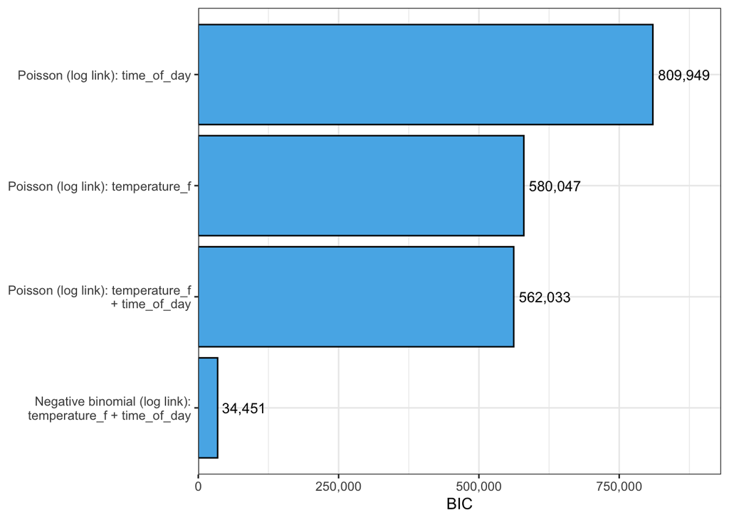

```r
# Creating comparison chart of model fit statistics
bind_rows(
  glance(poisson_temp) |> mutate(Model = "Poisson (log link): temperature_f", logLik = as.numeric(logLik)),
  glance(poisson_time) |> mutate(Model = "Poisson (log link): time_of_day", logLik = as.numeric(logLik)),
  glance(poisson_model) |> mutate(Model = "Poisson (log link): temperature_f + time_of_day", logLik = as.numeric(logLik)),
  glance(nb_model) |> mutate(Model = "Negative binomial (log link): temperature_f + time_of_day", logLik = as.numeric(logLik))
) |>
  ggplot(aes(x = BIC, y = reorder(Model, BIC))) +
  geom_col(fill = "#56B4E9", color = "black") +
  geom_text(
    aes(label = scales::comma(BIC, accuracy = 1)),
    hjust = -0.1,
    size = 3.5
  ) +
  scale_x_continuous(
    labels = scales::comma,
    expand = expansion(mult = c(0, 0.15)) # Adds padding to the right so text isn't cut off
  ) +
  scale_y_discrete(
    labels = scales::label_wrap(35) # Wraps long model names to ~2 lines
  ) +
  labs(
    x = "BIC",
    y = NULL
  ) +
  theme_bw()
```

**Tip**

1. Comparing the three Poisson GLMs (Models 1, 2, and 3) in Table 15, which Poisson model is preferred based on BIC? Does including both `temperature_f` and `time_of_day` improve model fit over using either predictor alone?
2. Which model is preferred overall based on the BIC values?

## Footnotes

[^1]: 1/(2*df)
[^2]: 1/(2*df)